# Tarea 4 Pig

Mariana Godina Abasolo

### Foto de tu clúster de AWS

- management console

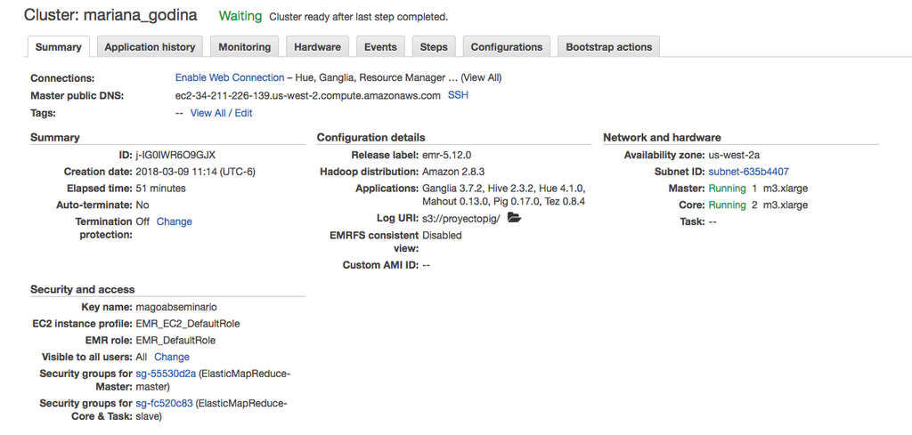

### Ejercicio A

- Modifica el ejercicio de Rank para que en lugar de obtener el id del producto con mejor rank obtengamos el nombre del producto -requieres un join- con el mejor rank
  - Raclette Courdavoult es el producto con mejor rank

```bash
cat ./EjercicioA/output_a
```

```
1,Raclette Courdavault,54
```

### Ejercicio B

1. ¿Cuántos vuelos existen en el dataset cuyo aeropuerto destino sea el “Honolulu International Airport”?
   - Existen 43,157 vuelos cuyo aeropuerto de destino es Honolulu International Airport.

```bash
cat ./EjercicioB/output_b1
```

```
HNL Honolulu International Airport  43157
```

2. ¿Cuál es el vuelo con más retraso? ¿De qué aerolínea es?
   - El vuelo con más retraso es el 1322 de American Airlines.

```bash
cat ./EjercicioB/output_b2
```

```
1322,AA,1971,AA,American Airlines Inc.
```

3. ¿Qué día es en el que más vuelos cancelados hay?
   - El día de la semana con más vuelos cancelados es Lunes(1)

```bash
cat ./EjercicioB/output_b3
```

```
1,1,21073
```

4. ¿Cuáles son los aeropuertos orígen con 17 cancelaciones?
   - DHN,Dothan Regional Airport
   - DIK,Dickinson Theodore Roosevelt Regional Airport
   - ESC,Delta County Airport

```bash
cat ./EjercicioB/output_b4
```

```
DHN,Dothan Regional Airport,Dothan,AL,USA,31.32134,-85.44963,DHN,17
DIK,Dickinson Theodore Roosevelt Regional Airport,Dickinson,ND,USA,46.79739,-102.80195,DIK,17
ESC,Delta County Airport,Escanaba,MI,USA,45.72267,-87.09373,ESC,17
```

5. ¿Cuál es el aeropuerto origen con más vuelos cancelados?
   - ORD,Chicago O’Hare International Airport

```bash
cat ./EjercicioB/output_b5
```

```
1,ORD,Chicago O'Hare International Airport,Chicago,IL,USA,41.9796,-87.90446,ORD,8548
```

6. ¿Cuál es el vuelo (flight number) con mayor diversidad de aeropuertos destino, cuáles son estos destinos? (ocupar bag te ayudará en esta pregunta)
- El vuelo con mayor diversidad de aeropuertos de destino es el 202

```bash
cat ./EjercicioB/output_b6
```

```
202,68,{(10140),(10397),(10423),(10693),(10721),(10821),(11292),(11433),(11986),(12266),(12402),(12478),(13232),(13487),(13830),(13930),(14057),(14100),(14107),(14122),(14683),(14747),(14831),(ATL),(AUS),(BDL),(BNA),(BOS),(BWI),(CAK),(CLE),(DCA),(DEN),(DTW),(EWR),(FLL),(FNT),(IAD),(IAH),(IND),(ITO),…
```